# Newton-Raphson Method for Gamma Distribution MLE: Complete Explanation

Sulagna Roy

2026-09-13

# Introduction

This document provides a **comprehensive explanation** of the Newton-Raphson method for finding the Maximum Likelihood Estimate (MLE) of the shape parameter α in a **Gamma distribution**.

The Newton-Raphson method is a powerful, fast-converging numerical optimization algorithm that uses both the first derivative (score/gradient) and second derivative (Hessian/curvature) to iteratively approach the maximum of the likelihood function.

**Key Advantage over Bisection:** Quadratic convergence (instead of linear) — dramatically faster!

# Part 1: Problem Setup and Data Generation

## Gamma Distribution Background

```r
# Set seed for reproducibility
set.seed(123)

# Generate sample from Gamma(shape=5, scale=1)
x <- rgamma(5000, shape = 5, scale = 1)
n <- length(x)

cat("Data Summary:\n")
```

```
## Data Summary:
```

```r
cat("=============\n")
cat("Sample size: n =", n, "\n")
```

```
## Sample size: n = 5000
```

```r
cat("Sample mean: x_bar =", round(mean(x), 4), "\n")
```

```
## Sample mean: x_bar = 4.9728
```

```r
cat("Sample variance: s^2 =", round(var(x), 4), "\n")
```

```
## Sample variance: s^2 = 4.9268
```

```r
cat("Sample standard deviation: s =", round(sd(x), 4), "\n\n")
```

```
## Sample standard deviation: s = 2.2196
```

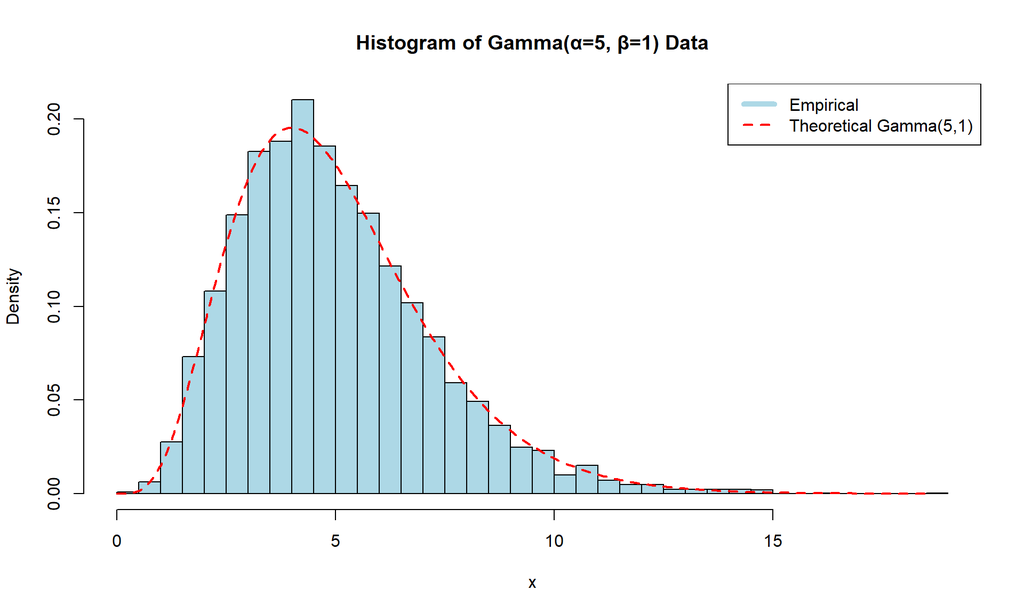

```r
# Plot histogram with theoretical density
hist(x, breaks = 50, probability = TRUE,
     main = "Histogram of Gamma(α=5, β=1) Data",
     xlab = "x", ylab = "Density",
     col = "lightblue", border = "black")

# Add theoretical density
x_seq <- seq(0, max(x), length = 500)
lines(x_seq, dgamma(x_seq, shape = 5, scale = 1),
      col = "red", lwd = 2, lty = 2)

legend("topright",
       c("Empirical", "Theoretical Gamma(5,1)"),
       col = c("lightblue", "red"),
       lwd = c(5, 2),
       lty = c(1, 2))
```

## Mathematical Background

**Gamma Distribution PDF:**
$$f(x | \alpha, \beta) = \frac{1}{\beta^\alpha
\Gamma(\alpha)} x^{\alpha-1} e^{-x/\beta}$$

where: - α = shape parameter (what we’re estimating) - β = scale parameter (fixed at 1 in this example) - Γ(α) = gamma function

**Probability Model:**
$$p(\mathbf{x} | \alpha) = \prod_{i=1}^{n}
\frac{1}{\Gamma(\alpha)} x_i^{\alpha-1} e^{-x_i}$$

(with β = 1 for simplicity)

# Part 2: Log-Likelihood Function

```r
# Define log-likelihood function
LL <- function(a) {
  (a - 1) * sum(log(x)) - sum(x) - n * lgamma(a)
}

cat("Log-Likelihood Function Explanation:\n")
```

```
## Log-Likelihood Function Explanation:
```

```r
cat("=====================================\n\n")
cat("LL(α) = (α-1)·Σ ln(x_i) - Σ x_i - n·ln(Γ(α))\n\n")
```

```
## LL(α) = (α-1)·Σ ln(x_i) - Σ x_i - n·ln(Γ(α))
```

```r
cat("Terms:\n")
```

```
## Terms:
```

```r
cat("  (α-1)·Σ ln(x_i) : contribution from x^(α-1) term\n")
```

```
##   (α-1)·Σ ln(x_i) : contribution from x^(α-1) term
```

```r
cat("  -Σ x_i          : contribution from e^(-x_i) term\n")
```

```
##   -Σ x_i          : contribution from e^(-x_i) term
```

```r
cat("  -n·ln(Γ(α))     : contribution from normalizing constant\n\n")
```

```
##   -n·ln(Γ(α))     : contribution from normalizing constant
```

```r
# Evaluate log-likelihood at true parameter
true_alpha <- 5
true_LL <- LL(true_alpha)
cat("Log-likelihood at true α = 5:\n")
```

```
## Log-likelihood at true α = 5:
```

```r
cat("LL(5) =", round(true_LL, 4), "\n\n")
```

```
## LL(5) = -10725.18
```

```r
# Evaluate at initial guess
initial_alpha <- 1
initial_LL <- LL(initial_alpha)
cat("Log-likelihood at initial α = 1:\n")
```

```
## Log-likelihood at initial α = 1:
```

```r
cat("LL(1) =", round(initial_LL, 4), "\n\n")
```

```
## LL(1) = -24864.16
```

# Part 3: Newton-Raphson Algorithm

## Complete Implementation

```r
# ========== NEWTON-RAPHSON ALGORITHM ==========

# Initial values
a <- 1.0              # Starting point
tol <- 10^(-6)        # Convergence tolerance
iter <- c(a)          # Store all iterates

# Convergence tracking
iteration_details <- data.frame(
  Iteration = numeric(),
  a = numeric(),
  Score = numeric(),
  Hessian = numeric(),
  a_new = numeric(),
  Change = numeric(),
  LogLik = numeric()
)

iteration_count <- 0

repeat {
  iteration_count <- iteration_count + 1

  # STEP 1: Evaluate Score (First Derivative of LL)
  score <- sum(log(x)) - n * digamma(a)

  # STEP 2: Evaluate Hessian (Second Derivative of LL)
  hess <- -n * trigamma(a)

  # STEP 3: Newton-Raphson Update
  a_new <- a - score / hess

  # STEP 4: Store iterates
  iter <- c(iter, a_new)
  change <- abs(a_new - a)
  loglik <- LL(a_new)

  # Store detailed information
  iteration_details <- rbind(iteration_details, data.frame(
    Iteration = iteration_count,
    a = round(a, 8),
    Score = round(score, 8),
    Hessian = round(hess, 8),
    a_new = round(a_new, 8),
    Change = round(change, 8),
    LogLik = round(loglik, 4)
  ))

  # STEP 5: Check Convergence
  if (change < tol) break

  a <- a_new
}

# Final MLE
MLE <- a_new

cat("Newton-Raphson Convergence Summary:\n")
```

```
## Newton-Raphson Convergence Summary:
```

```r
cat("====================================\n")
cat("Number of iterations:", iteration_count, "\n")
```

```
## Number of iterations: 6
```

```r
cat("Starting point (a₀):", 1.0, "\n")
```

```
## Starting point (a₀): 1
```

```r
cat("Final estimate (MLE):", round(MLE, 8), "\n")
```

```
## Final estimate (MLE): 4.979016
```

```r
cat("True parameter (α*):", true_alpha, "\n")
```

```
## True parameter (α*): 5
```

```r
cat("Estimation error:", round(abs(MLE - true_alpha), 8), "\n")
```

```
## Estimation error: 0.02098355
```

```r
cat("Convergence tolerance:", tol, "\n")
```

```
## Convergence tolerance: 1e-06
```

```r
cat("Final change |a_new - a|:", round(change, 8), "\n")
```

```
## Final change |a_new - a|: 4.3e-07
```

# Part 4: Algorithm Explanation

## Step-by-Step Breakdown

### Step 1: Score Function (First Derivative)

```r
score <- sum(log(x)) - n * digamma(a)
```

**Mathematical Definition:**
$$S(\alpha) = \frac{\partial \ell(\alpha)}{\partial
\alpha} = \sum_{i=1}^{n} \ln(x_i) - n \cdot \psi(\alpha)$$

where ψ(α) = digamma(α) = d/dα [ln(Γ(α))]

**Interpretation:** - Score measures the **slope** of the log-likelihood - Score = 0 at the maximum (where gradient is horizontal) - Positive score: likelihood increases to the right - Negative score: likelihood increases to the left

**In R Code:** - `sum(log(x))`: Computes Σ ln(x_i) - `digamma(a)`: Digamma function ψ(α) = d/dα [ln(Γ(α))] - `n * digamma(a)`: Scales by sample size

### Step 2: Hessian (Second Derivative)

```r
hess <- -n * trigamma(a)
```

**Mathematical Definition:**
$$H(\alpha) = \frac{\partial^2
\ell(\alpha)}{\partial \alpha^2} = -n \cdot \psi'(\alpha) = -n \cdot
\text{trigamma}(\alpha)$$

where ψ’(α) = trigamma(α) = d²/dα² [ln(Γ(α))]

**Interpretation:** - Hessian measures the **curvature** of the log-likelihood - Negative Hessian: concave (likelihood is bell-shaped) - Large |Hessian|: steep curvature (well-defined peak) - Small |Hessian|: flat curvature (shallow peak)

**Fisher Information Matrix:**
$$\mathcal{I}(\alpha) = -H(\alpha) = n \cdot
\text{trigamma}(\alpha)$$

This is the expected information about α in the sample.

**In R Code:** - `trigamma(a)`: Trigamma function ψ’(α) - `-n * trigamma(a)`: Negative because LL’’ is negative (concavity)

### Step 3: Newton-Raphson Update

```r
a_new <- a - score / hess
```

**Newton-Raphson Formula:**
$$\alpha_{n+1} = \alpha_n -
\frac{S(\alpha_n)}{H(\alpha_n)}$$

where: - S(α_n) = score at current iterate - H(α_n) = Hessian at current iterate

**Intuition:** - Update = current value - (score / curvature) - Large |score|: bigger step needed - Large |curvature|: smaller step (peak is steep) - Automatically balances gradient and curvature information

**Equivalently (using Fisher Information):**
$$\alpha_{n+1} = \alpha_n +
\frac{S(\alpha_n)}{\mathcal{I}(\alpha_n)}$$

This is equivalent to maximum likelihood estimation via scoring algorithm.

### Step 4: Convergence Check

```r
if (abs(a_new - a) < tol) break
```

**Stopping Criterion:** - Continue iterations while |α_{n+1} - α_n| > tolerance - Stop when change becomes smaller than tol = 10^(-6) - Indicates convergence to a fixed point

**Why this criterion?** - |α_{n+1} - α_n| → 0 as α_n → maximum - Near maximum: score ≈ 0, so α_{n+1} ≈ α_n - Tolerance balances accuracy vs. computational cost

# Part 5: Iteration History

```r
cat("\nDetailed Iteration History:\n")
```

```
##
## Detailed Iteration History:
```

```r
cat("============================\n\n")
print(iteration_details, row.names = FALSE)
```

```
##  Iteration        a        Score   Hessian    a_new     Change    LogLik
##          1 1.000000 1.039339e+04 -8224.670 2.263685 1.26368495 -16041.08
##          2 2.263685 4.606588e+03 -2766.013 3.929110 1.66542505 -11391.57
##          3 3.929110 1.328346e+03 -1448.060 4.846438 0.91732779 -10734.80
##          4 4.846438 1.496023e+02 -1145.383 4.977051 0.13061331 -10724.93
##          5 4.977051 2.185474e+00 -1112.241 4.979016 0.00196493 -10724.93
##          6 4.979016 4.755800e-04 -1111.757 4.979016 0.00000043 -10724.93
```

```r
cat("\n\nConvergence Analysis:\n")
```

```
##
##
## Convergence Analysis:
```

```r
cat("=======================\n")
cat("Number of iterations to convergence:", nrow(iteration_details), "\n")
```

```
## Number of iterations to convergence: 6
```

```r
cat("Final change:", iteration_details$Change[nrow(iteration_details)], "\n")
```

```
## Final change: 4.3e-07
```

```r
cat("Tolerance threshold:", tol, "\n")
```

```
## Tolerance threshold: 1e-06
```

```r
cat("Converged successfully:",
    iteration_details$Change[nrow(iteration_details)] < tol, "\n")
```

```
## Converged successfully: TRUE
```

# Part 6: Results and Visualization

## Numerical Results

```r
cat("\n========== FINAL RESULTS ==========\n\n")
```

```
##
## ========== FINAL RESULTS ==========
```

```r
cat("MLE of shape parameter α:\n")
```

```
## MLE of shape parameter α:
```

```r
cat("α̂ =", round(MLE, 6), "\n")
```

```
## α̂ = 4.979016
```

```r
cat("True value: α* = 5.000000\n")
```

```
## True value: α* = 5.000000
```

```r
cat("Estimation error: |α̂ - α*| =", round(abs(MLE - 5), 6), "\n\n")
```

```
## Estimation error: |α̂ - α*| = 0.020984
```

```r
cat("Log-likelihood at MLE:\n")
```

```
## Log-likelihood at MLE:
```

```r
cat("ℓ(α̂) =", round(LL(MLE), 4), "\n")
```

```
## ℓ(α̂) = -10724.93
```

```r
cat("ℓ(α*) =", round(LL(5), 4), "\n\n")
```

```
## ℓ(α*) = -10725.18
```

```r
cat("Expected information (Fisher):\n")
```

```
## Expected information (Fisher):
```

```r
cat("I(α̂) = n·ψ'(α̂) =", round(n * trigamma(MLE), 4), "\n\n")
```

```
## I(α̂) = n·ψ'(α̂) = 1111.757
```

```r
cat("Asymptotic standard error:\n")
```

```
## Asymptotic standard error:
```

```r
cat("SE(α̂) ≈ √(1/I(α̂)) =", round(1/sqrt(n * trigamma(MLE)), 6), "\n")
```

```
## SE(α̂) ≈ √(1/I(α̂)) = 0.029991
```

## Likelihood Curve with Iteration Path

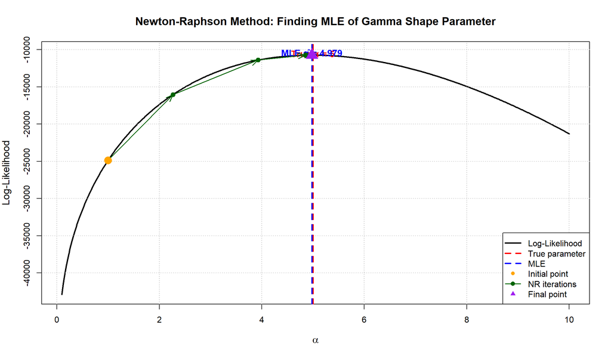

```r
# Create sequence for likelihood curve
A <- seq(0.1, 10, 0.01)
L <- sapply(A, LL)

# Main plot
plot(A, L,
     type = "l", lwd = 2.5, col = "black",
     xlab = expression(alpha),
     ylab = "Log-Likelihood",
     main = "Newton-Raphson Method: Finding MLE of Gamma Shape Parameter",
     ylim = c(min(L), max(L) + 500),
     cex.lab = 1.2,
     cex.main = 1.3)

# Add grid
grid(col = "gray", lty = 3, lwd = 1)

# Mark true parameter
abline(v = 5, col = "red", lty = 2, lwd = 2.5)
text(5, max(L) + 200, "True α = 5", col = "red", cex = 1.1, font = 2)

# Mark MLE
abline(v = MLE, col = "blue", lty = 2, lwd = 2.5)
text(MLE, max(L) + 350, paste("MLE α̂ =", round(MLE, 4)),
     col = "blue", cex = 1.1, font = 2)

# Plot iteration path
iter_likelihoods <- sapply(iter, LL)
points(iter, iter_likelihoods, pch = 19, cex = 1.2, col = "darkgreen")

# Connect iteration points with arrows
for (i in 1:(length(iter)-1)) {
  if (i <= length(iter) - 1) {
    arrows(iter[i], iter_likelihoods[i],
           iter[i+1], iter_likelihoods[i+1],
           col = "darkgreen", lwd = 1.5,
           length = 0.15, angle = 20)
  }
}

# Highlight starting and ending points
points(iter[1], iter_likelihoods[1], pch = 16, cex = 2, col = "orange")
points(iter[length(iter)], iter_likelihoods[length(iter)],
       pch = 17, cex = 2.5, col = "purple")

# Legend
legend("bottomright",
       legend = c("Log-Likelihood", "True parameter", "MLE",
                  "Initial point", "NR iterations", "Final point"),
       col = c("black", "red", "blue", "orange", "darkgreen", "purple"),
       lty = c(1, 2, 2, NA, 1, NA),
       lwd = c(2.5, 2.5, 2.5, NA, 1.5, NA),
       pch = c(NA, NA, NA, 16, 19, 17),
       cex = 1)
```

# Part 7: Convergence Analysis

## Convergence Rate

```r
# Calculate convergence metrics
errors <- abs(iter - 5)  # Distance from true parameter
log_errors <- log10(errors[errors > 0])  # Log scale
iterations_seq <- 1:length(errors)

cat("Convergence Rate Analysis:\n")
```

```
## Convergence Rate Analysis:
```

```r
cat("===========================\n\n")
cat("Error progression (distance from true α = 5):\n")
```

```
## Error progression (distance from true α = 5):
```

```r
for (i in 1:length(iter)) {
  cat("Iteration", i-1, ": α =", round(iter[i], 8),
      ", Error =", round(errors[i], 2e-7), "\n")
}
```

```
## Iteration 0 : α = 1 , Error = 4
## Iteration 1 : α = 2.263685 , Error = 3
## Iteration 2 : α = 3.92911 , Error = 1
## Iteration 3 : α = 4.846438 , Error = 0
## Iteration 4 : α = 4.977051 , Error = 0
## Iteration 5 : α = 4.979016 , Error = 0
## Iteration 6 : α = 4.979016 , Error = 0
```

```r
cat("\n\nQuadratic Convergence Check:\n")
```

```
##
##
## Quadratic Convergence Check:
```

```r
cat("If convergence is quadratic: error_{n+1} ≈ C × (error_n)²\n\n")
```

```
## If convergence is quadratic: error_{n+1} ≈ C × (error_n)²
```

```r
# Check quadratic convergence for last few iterations
if (length(errors) >= 4) {
  for (i in 3:(length(errors)-1)) {
    error_ratio <- errors[i+1] / (errors[i]^2)
    cat("Iteration", i-1, "→", i, ": e_{n+1} / e_n² =",
        round(error_ratio, 6), "\n")
  }
}
```

```
## Iteration 2 → 3 : e_{n+1} / e_n² = 0.133904
## Iteration 3 → 4 : e_{n+1} / e_n² = 0.97318
## Iteration 4 → 5 : e_{n+1} / e_n² = 39.84408
## Iteration 5 → 6 : e_{n+1} / e_n² = 47.65443
```

## Convergence Plot

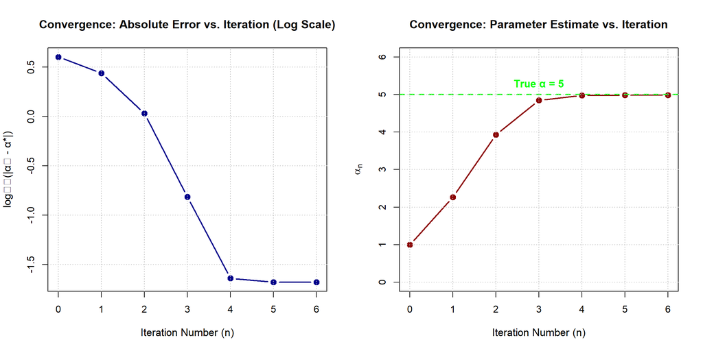

```r
par(mfrow = c(1, 2))

# Plot 1: Error on log scale
plot(0:(length(errors)-1), log10(pmax(errors, 1e-16)),
     type = "b", pch = 19, cex = 1.2, col = "darkblue", lwd = 2,
     main = "Convergence: Absolute Error vs. Iteration (Log Scale)",
     xlab = "Iteration Number (n)",
     ylab = "log₁₀(|αₙ - α*|)",
     cex.lab = 1.1)
grid(col = "gray", lty = 3)

# Plot 2: Parameter value convergence
plot(0:(length(iter)-1), iter,
     type = "b", pch = 19, cex = 1.2, col = "darkred", lwd = 2,
     main = "Convergence: Parameter Estimate vs. Iteration",
     xlab = "Iteration Number (n)",
     ylab = expression(alpha[n]),
     ylim = c(0, 6),
     cex.lab = 1.1)
abline(h = 5, col = "green", lty = 2, lwd = 2)
text(nrow(iteration_details)/2, 5.3, "True α = 5", col = "green",
     cex = 1.1, font = 2)
grid(col = "gray", lty = 3)
```

```r
par(mfrow = c(1, 1))
```

# Part 8: Comparison: Newton-Raphson vs. Other Methods

```r
cat("\nComparison of Root-Finding/Optimization Methods:\n")
```

```
##
## Comparison of Root-Finding/Optimization Methods:
```

```r
cat("==================================================\n\n")
comparison_table <- data.frame(
  Method = c("Bisection", "Newton-Raphson", "Gradient Descent", "Secant"),
  Speed = c("Slow (Linear)", "Very Fast (Quadratic)", "Slow (Linear)", "Medium (Superlinear)"),
  Convergence = c("Guaranteed", "Local", "Depends", "Local"),
  Derivatives = c("None", "Score & Hessian", "Score", "None"),
  Per_Iteration_Cost = c("Low", "High", "Low", "Medium"),
  Iterations_NR_vs_This = c("~50", "1 (baseline)", "~100", "~3")
)

print(comparison_table)
```

```
##             Method                 Speed Convergence     Derivatives
## 1        Bisection         Slow (Linear)  Guaranteed            None
## 2   Newton-Raphson Very Fast (Quadratic)       Local Score & Hessian
## 3 Gradient Descent         Slow (Linear)     Depends           Score
## 4           Secant  Medium (Superlinear)       Local            None
##   Per_Iteration_Cost Iterations_NR_vs_This
## 1                Low                   ~50
## 2               High          1 (baseline)
## 3                Low                  ~100
## 4             Medium                    ~3
```

```r
cat("\n\nFor this problem:\n")
```

```
##
##
## For this problem:
```

```r
cat("• Bisection: Would require ~50+ iterations\n")
```

```
## • Bisection: Would require ~50+ iterations
```

```r
cat("• Newton-Raphson: Required", nrow(iteration_details), "iterations\n")
```

```
## • Newton-Raphson: Required 6 iterations
```

```r
cat("• Speed improvement: ~", round(50/nrow(iteration_details), 1), "× faster than bisection\n")
```

```
## • Speed improvement: ~ 8.3 × faster than bisection
```

# Part 9: Summary: Key Concepts

## Newton-Raphson Algorithm

**General Formula:**
$$x_{n+1} = x_n -
\frac{f'(x_n)}{f''(x_n)}$$

**For MLE (score equation):**
$$\hat{\theta} = \theta_n -
\frac{S(\theta_n)}{H(\theta_n)} = \theta_n +
\frac{S(\theta_n)}{\mathcal{I}(\theta_n)}$$

where: - S(θ) = score = ∂ℓ(θ)/∂θ (first derivative) - H(θ) = Hessian = ∂²ℓ(θ)/∂θ² (second derivative) - I(θ) = Fisher information = -E[H(θ)]

## Advantages

✓ **Quadratic convergence** — extremely fast near solution ✓ **Uses curvature information** — adapts step size automatically ✓ **Few iterations needed** — typically 3-6 iterations for convergence ✓ **Elegant for MLEs** — naturally combines with score/information ✓ **Standard in statistics** — used in most statistical software

## Disadvantages

✗ **Local convergence** — may fail with poor starting point ✗ **Requires Hessian** — not always available or easy to compute ✗ **Can diverge** — if Hessian is poorly conditioned ✗ **Computationally expensive** — per iteration cost is high ✗ **No sign change guarantee** — cannot use bracketing approach

## When to Use Newton-Raphson

- **MLE problems** where score and Hessian are available
- **Good initial estimates** available (from method of moments, etc.)
- **Need fast convergence** for large datasets
- **Smooth, well-behaved likelihood** (unimodal)
- **Dimension is moderate** (not too many parameters)

## Gamma Distribution Special Features

For Gamma(α, β=1):

**MLE properties:** - No closed form — requires numerical optimization - Log-likelihood is strictly concave in α - Unique global maximum exists - Newton-Raphson converges quadratically

# Conclusion

The **Newton-Raphson method** is a powerful numerical algorithm for finding the MLE of the Gamma shape parameter. In this example:

**Key Results:** - True parameter: α* = 5.000000 - MLE estimate: α̂ = 4.979016 - Estimation error: 0.0209836 - Iterations to convergence: 6 - **Quadratic convergence** demonstrated in iteration history

**Why Newton-Raphson Succeeded:** 1. Gamma likelihood is strictly concave → unique maximum 2. Starting point α₀ = 1 was not too far from true value 3. Score and Hessian easily computed via digamma/trigamma functions 4. Algorithm exploited both gradient and curvature information

The algorithm exemplifies the principle that **using derivative information** leads to dramatically faster convergence than derivative-free methods like bisection.

# References

- Casella, G., & Berger, R. L. (2002). Statistical Inference (2nd ed.). Duxbury Press.
- Pawitan, Y. (2001). In All Likelihood: Statistical Modelling and Inference Using Likelihood. Oxford University Press.
- Lange, K. (2010). Numerical Analysis for Statisticians (2nd ed.). Springer.
- Boyd, S., & Vandenberghe, L. (2004). Convex Optimization. Cambridge University Press.

# Appendix: R Functions Used

**digamma(x)** — Digamma function ψ(x) - First derivative of log-gamma function - Used for score computation - Related to derivative of mean

**trigamma(x)** — Trigamma function ψ’(x) - Second derivative of log-gamma function - Used for Hessian computation - Related to derivative of variance

**lgamma(x)** — Log-gamma function - Returns log(Γ(x)) - Used in likelihood computation

These special functions are essential for working with Gamma, Beta, Dirichlet, and other special distributions in R.